### CD16 Mono

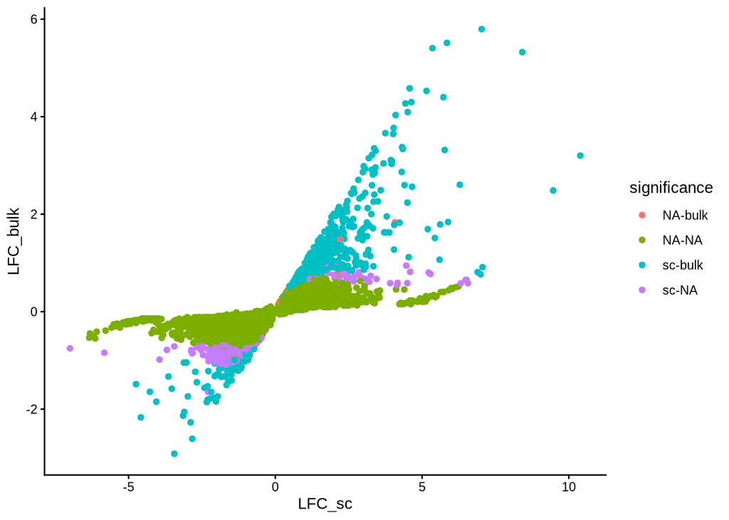

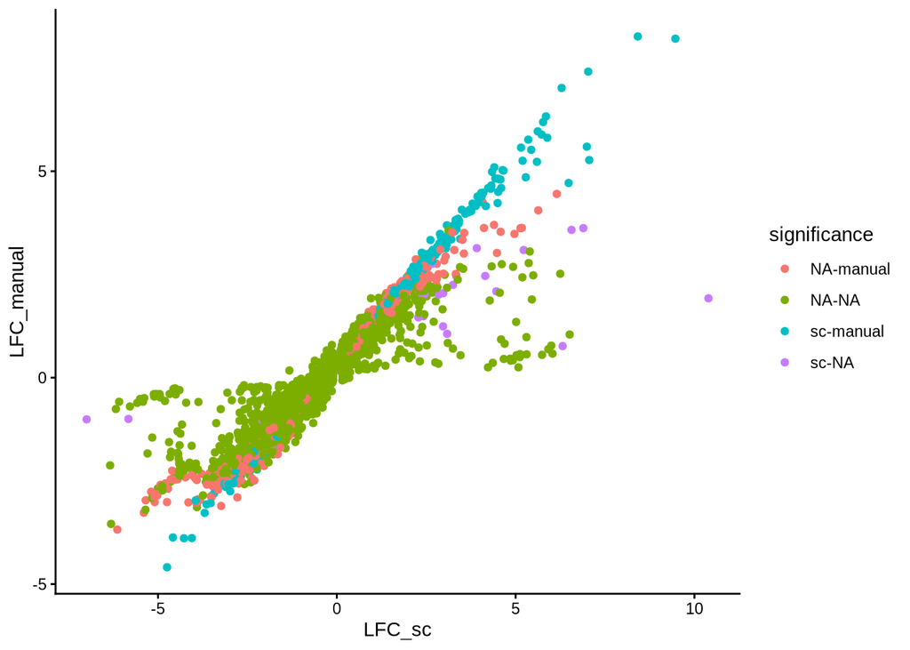

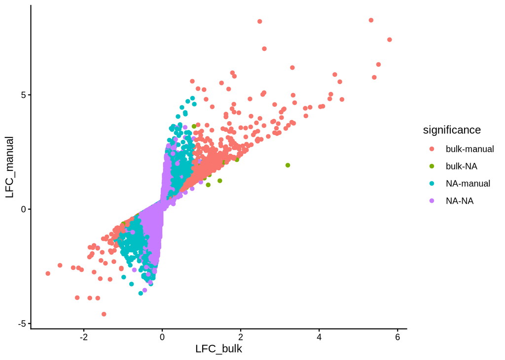

### NK

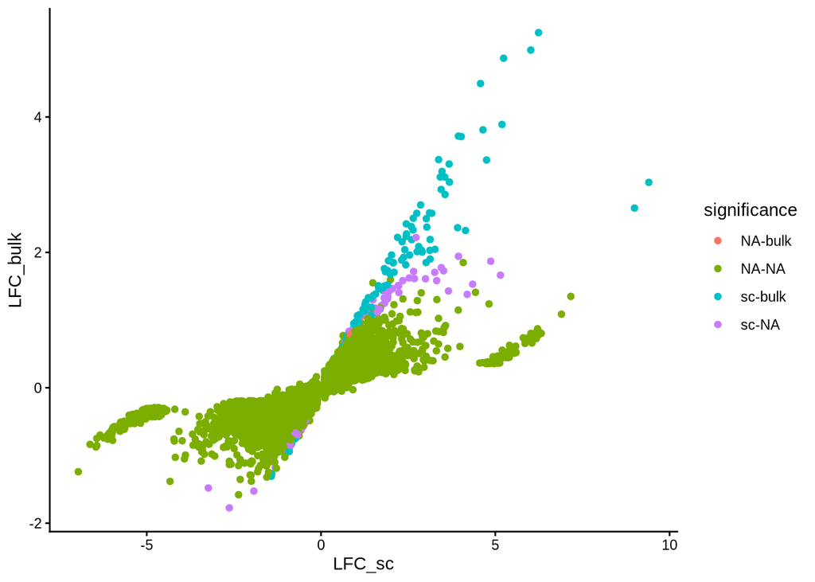

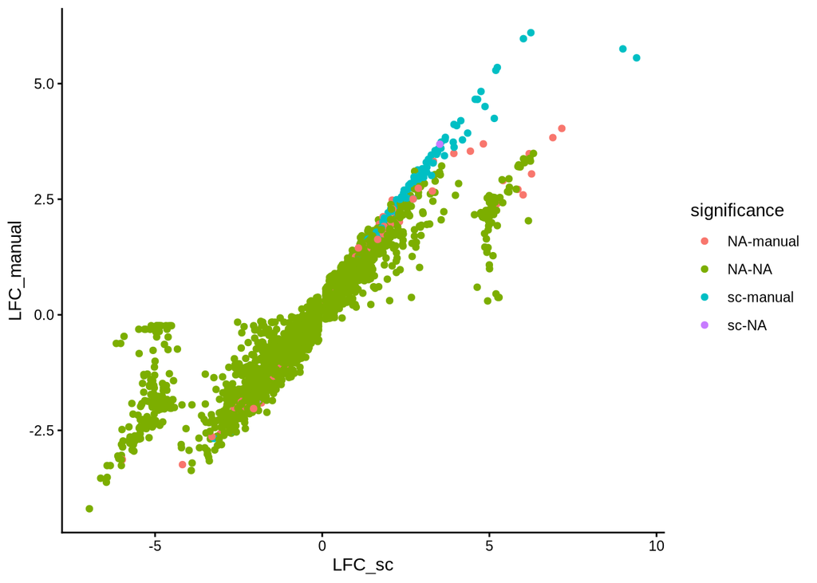

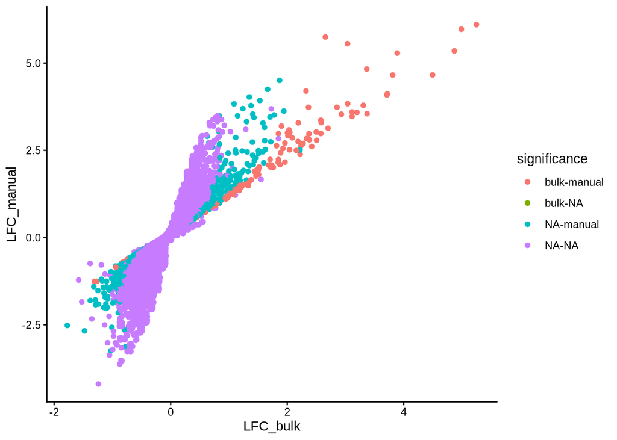

### Eryth

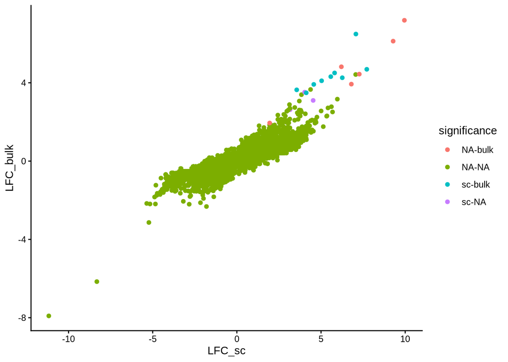

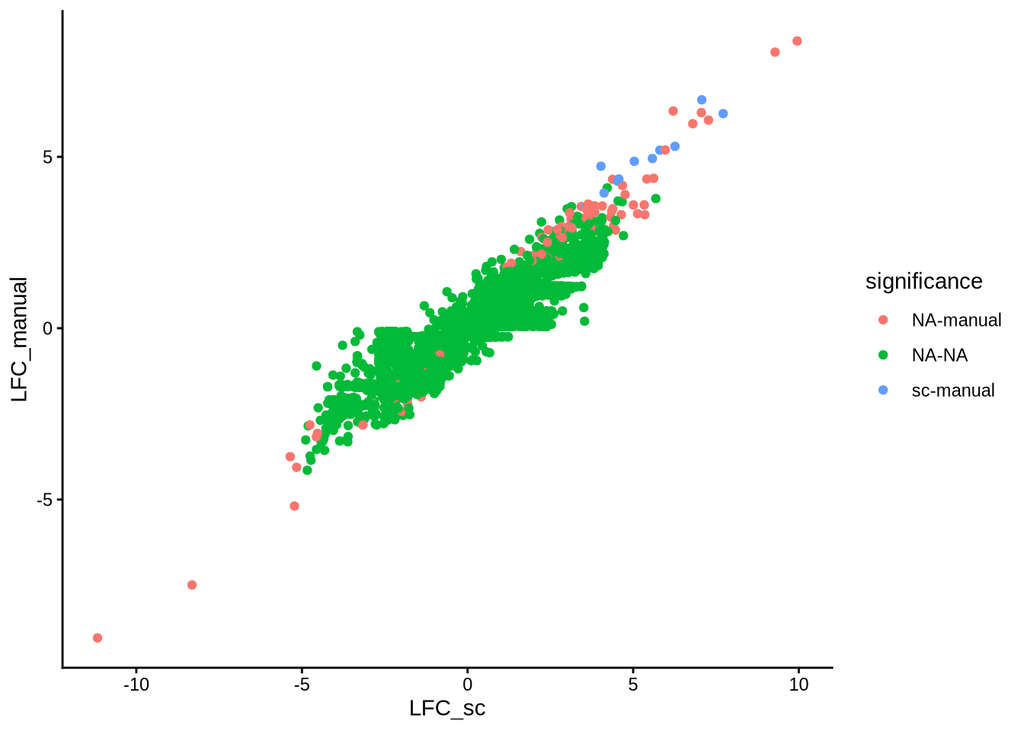

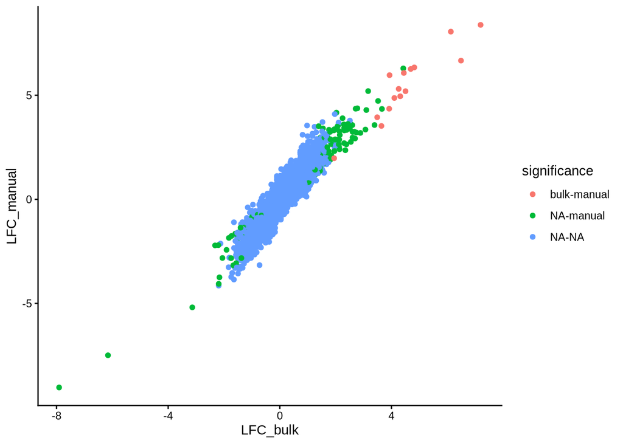

For simplicity, the same threshold of adjusted p-values of 0.1 was used to label the genes as significant for each of the approaches, but they are using different statistical tests (Seurat vs. manual DESeq2), based on different genes background (Seurat vs. manual DESeq2) and different number of samples (single cell vs. pseudobulk). Thus it is not surprising that the adjusted p-values differ. The LFCs, while not identical, at least are following the same trend.